# Volesti tutorial

```r
exact <- 2^d*100
cat("exact volume                 = ", exact , "\n")
```

```
## exact volume                 =  102400
```

```r
cat("volume estimation (no round) = ", volume(P, WalkType = "RDHR",
rounding=FALSE), "\n")
```

```
## volume estimation (no round) =  31510.74964
```

```r
cat("volume estimation (rounding) = ", volume(P, WalkType = "RDHR",
rounding=TRUE), "\n")
```

```
## volume estimation (rounding) =  70094.39036
```

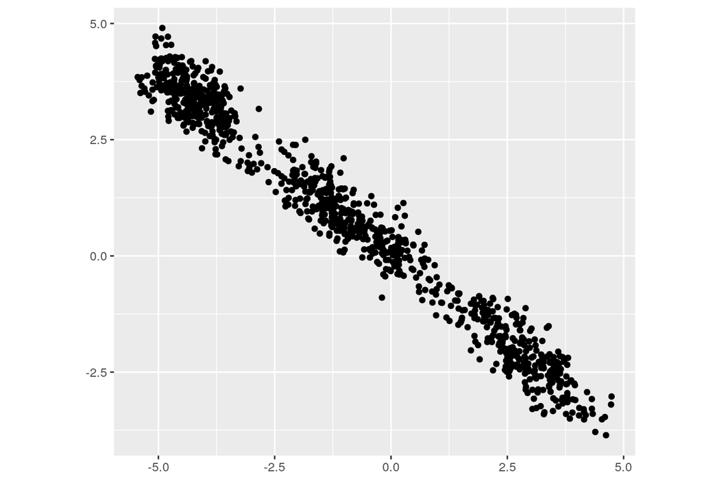

```r
# 1st step of rounding
res1 = round_polytope(P)
points2 = sample_points(res1$P, WalkType = "RDHR", N=1000)
ggplot(data.frame(x = c(points2[1,]), y = c(points2[2,])), aes(x=x,
y=y)) + geom_point() +labs(x =" ", y = " ")+coord_fixed()
```

```r
volesti <- volume(res1$P) * res1$round_value
cat("volume estimation (1st step) = ", volesti, " rel. error=",
abs(exact-volesti)/exact,"\n")
```

```
## volume estimation (1st step) =  87990.82323  rel. error= 0.1407146169
```

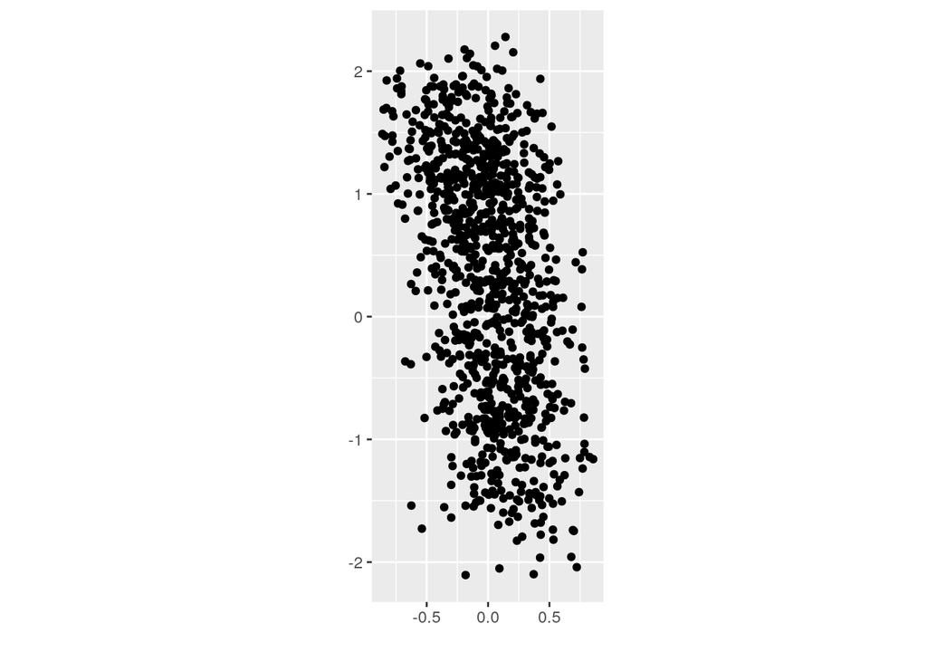

```r
# 2nd step of rounding
res2 = round_polytope(res1$P)
points2 = sample_points(res2$P, WalkType = "RDHR", N=1000)
ggplot(data.frame(x = c(points2[1,]), y = c(points2[2,])), aes(x=x,
y=y)) + geom_point() +labs(x =" ", y = " ")+coord_fixed()
```

```r
volesti <- volume(res2$P) * res1$round_value * res2$round_value
cat("volume estimation (2nd step) = ", volesti, " rel. error=",
abs(exact-volesti)/exact,"\n")
```

```
## volume estimation (2nd step) =  85379.73771  rel. error= 0.1662134989
```

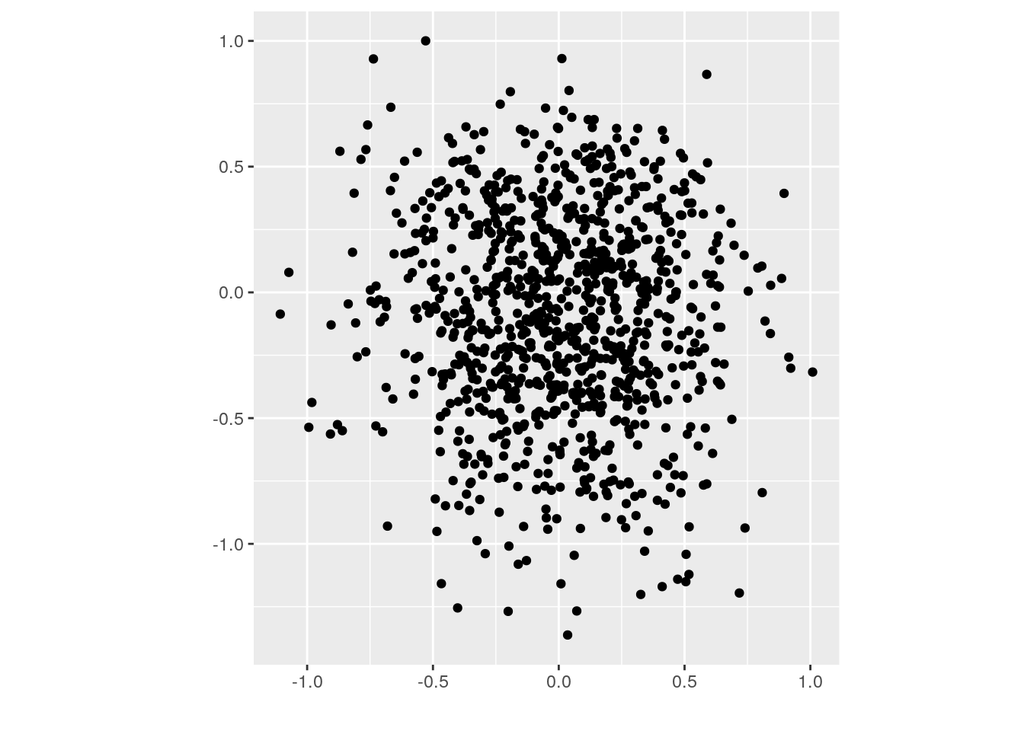

```r
# 3rd step of rounding
res3 = round_polytope(res2$P)
points2 = sample_points(res3$P, WalkType = "RDHR", N=1000)
ggplot(data.frame(x = c(points2[1,]), y = c(points2[2,])), aes(x=x,
y=y)) + geom_point() +labs(x =" ", y = " ")+coord_fixed()
```

```r
volesti <- volume(res3$P) * res1$round_value * res2$round_value *
res3$round_value
cat("volume estimation (3rd step) = ", volesti, " rel. error=",
abs(exact-volesti)/exact,"\n")
```

```
## volume estimation (3rd step) =  101028.4689  rel. error= 0.01339385839
```

# Integration

We can use sampling and volume estimation to estimate integrals over polyhedral domains. Below there is an example with a degree 2 polynomial over a 3-dimensional cube.

```r
library(cubature) # load the package "cubature"
f <- function(x) { 2/3 * (2 * x[1]^2 + x[2] + x[3]) + 10 }  # "x" is vector
adaptIntegrate(f, lowerLimit = c(-1, -1, -1), upperLimit = c(1, 1, 1))$integral
```

```
## [1] 83.55555556
```

```r
# Simple Monte Carlo integration
# https://en.wikipedia.org/wiki/Monte_Carlo_integration
P = GenCube(3, 'H')
num_of_points <- 10000
points1 <- sample_points(P, WalkType = "RDHR", walk_step = 100, N=num_of_points)
int<-0
for (i in 1:num_of_points){
  int <- int + f(points1[,i])
}
V <- volume(P)
print(int*V/num_of_points)
```

```
## [1] 83.44445883
```

# Counting linear extensions

Let $G= (V, E)$ be an acyclic digraph with $V= [n] :=\{1,2, . . . , n\}$. One might want to consider $G$ as a representation of the partially ordered set (poset) $V:i > j$ if and only if there is a directed path from node $i$ to node $j$.A permutation $\pi$ of $[n]$ is called a linear extension of $G$ (or the associated poset $V$) if $\pi^{-1}(i)> \pi^{-1}(j)$ for every edge $i\rightarrow j \in E$.

Let $P_{LE}(G)$ be the polytope in $R^n$ defined by $P_{LE}(G) =\{x\in R^n\ |\ 1\geq x_i \geq 0 \text{ for all }i=1,2,\dots ,n$, and $x_i\geq x_j$ for all directed edges $i\rightarrow j \in E$.

A well known result is $\#_{LE}G=vol(P)*n!$.

The following example from https://inf.ethz.ch/personal/fukudak/lect/pclect/notes2016/expoly_order.pdf has $9$ linear extensions. See also https://www.aaai.org/ocs/index.php/AAAI/AAAI18/paper/viewFile/16957/15838 for counting linear extensions in practice.

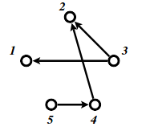

graph

We can approximate this number by the following code.

```r
A = matrix(c(-1,0,1,0,0,0,-1,1,0,0,0,-1,0,1,0,0,0,0,-1,1,1,0,0,0,0,0,1,0,0,0,0,0,1,0,0,0,0,0,1,0,0,0,0,0,1,-1,0,0,0,0,0,-1,0,0,0,0,0,-1,0,0,0,0,0,-1,0,0,0,0,0,-1),
ncol=5, nrow=14, byrow=TRUE)
b = c(0,0,0,0,0,0,0,0,0,1,1,1,1,1)
P = Hpolytope$new(A, b)
volume(P,error=0.2)*factorial(5)
```

```
## [1] 9.130753313
```

# Questions

## Volume of intersection of polytopes

How can we compute the volume of the intersection of two V-polytopes? What is the complexity? Can you provide any implementations (deterministic or randomized).

## Volume of Minkowski sums

The Minkowski sum of two sets (e.g. polytopes) A and B in Euclidean space is formed by adding each vector in A to each vector in B, i.e., the set
$${\displaystyle A+B=\{a +b \ |\ a \in A,\ b \in B\}.}$$

1. Describe an algorithm for the volume of the Minkowski sum.
2. What is the complexity of your algorithm?
3. Implement you algorithm.

## Density estimation / non parametric statistics

Can you estimate the density of a sample generate by `volesti`? Hint: `R` package `LogConcDEAD`